# Analysis of CollegeScores4yr Dataset

## 3.5 **5️⃣ Histogram: Tuition Fees**

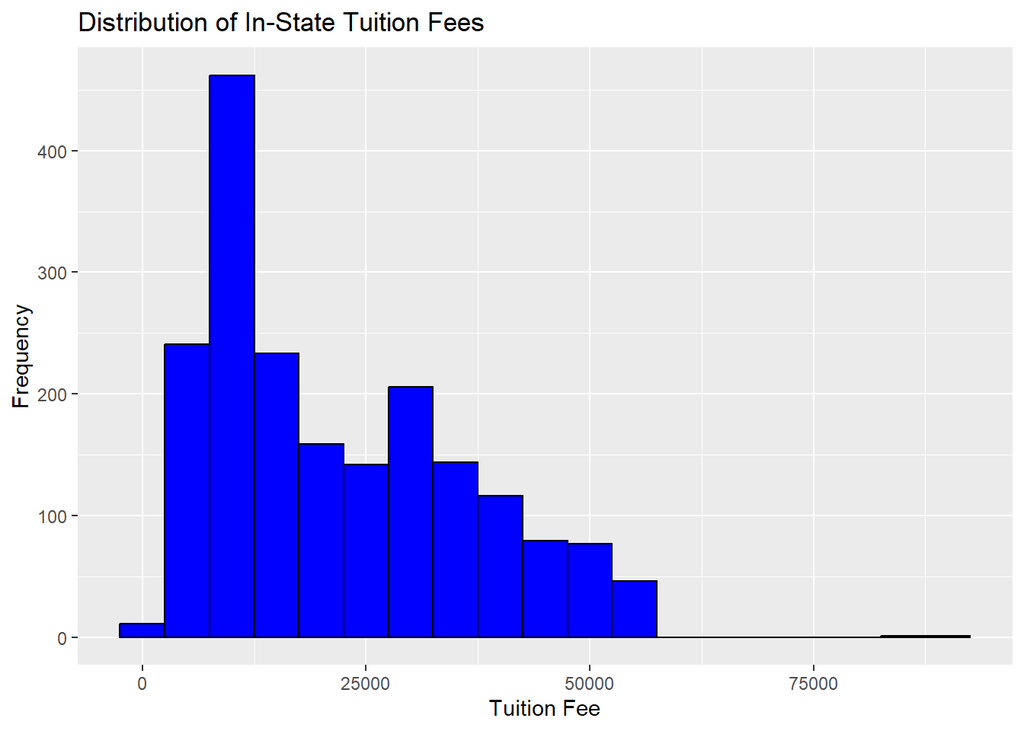

```r
ggplot(college_data, aes(x = TuitionIn)) +
  geom_histogram(binwidth = 5000, fill = "blue", color = "black") +
  labs(title = "Distribution of In-State Tuition Fees", x = "Tuition Fee", y = "Frequency")
```

## 3.6 **6️⃣ Boxplot: Acceptance Rates**

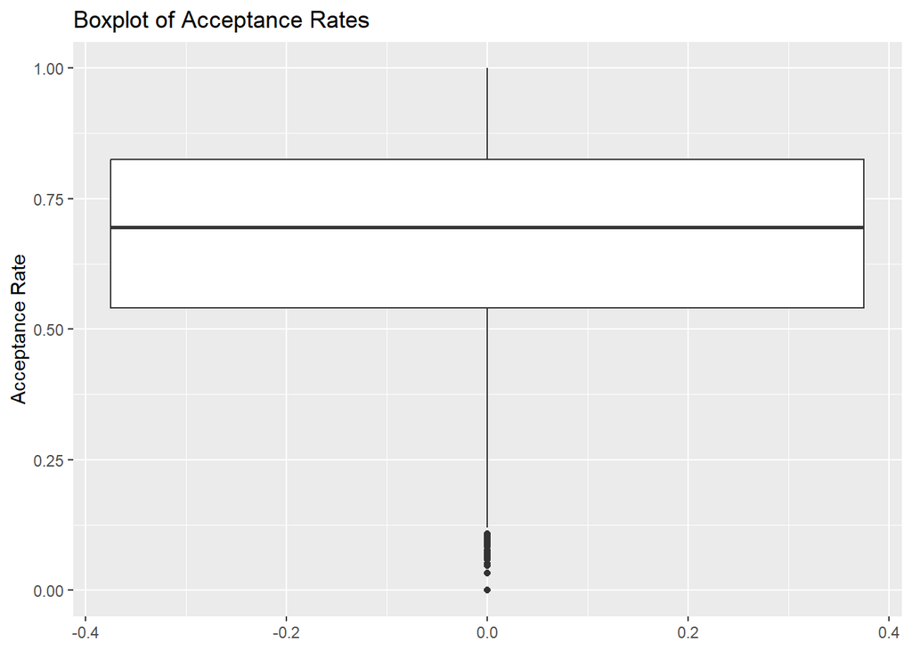

```r
ggplot(college_data, aes(y = AdmitRate)) +
  geom_boxplot() +
  labs(title = "Boxplot of Acceptance Rates", y = "Acceptance Rate")
```

## 3.7 **7️⃣ Correlation: SAT Scores & Graduation Rates**

```r
correlation <- cor(college_data$AvgSAT, college_data$CompRate, use = "complete.obs")
correlation
```

```
## [1] 0.8189495
```

## 3.8 **8️⃣ Pie Chart: Public vs. Private Colleges**

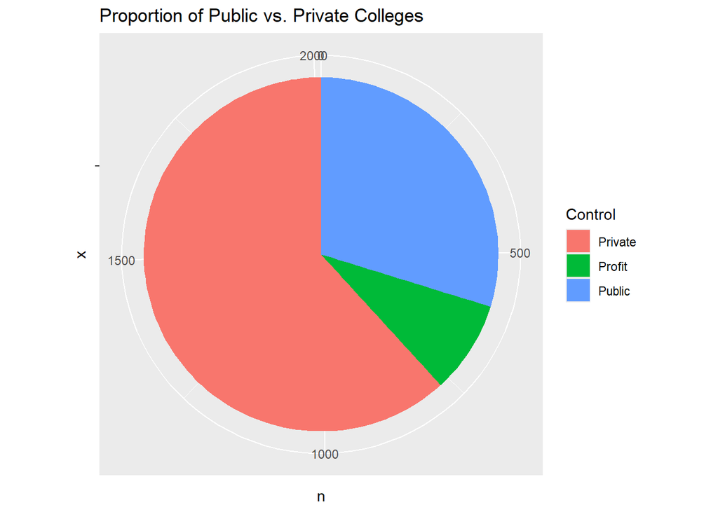

```r
college_data %>%
  count(Control) %>%
  ggplot(aes(x = "", y = n, fill = Control)) +
  geom_bar(stat = "identity", width = 1) +
  coord_polar("y") +
  labs(title = "Proportion of Public vs. Private Colleges")
```

## 3.9 **9️⃣ Bar Chart: Tuition Fees for Public vs. Private**

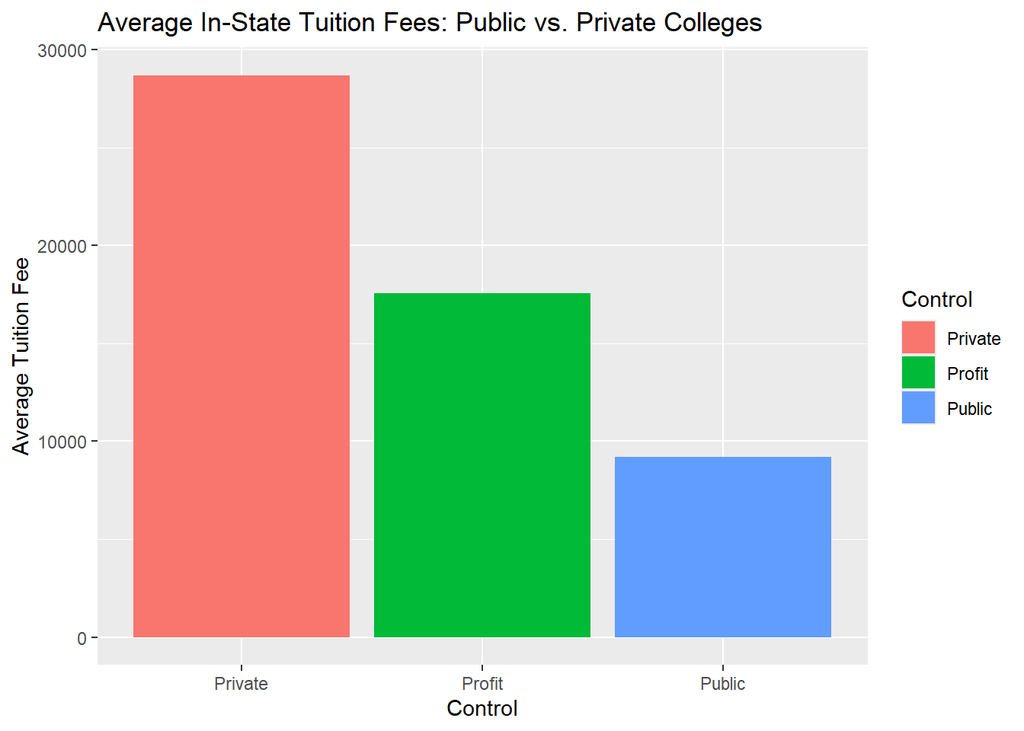

```r
college_data %>%
  group_by(Control) %>%
  summarise(avg_tuition = mean(TuitionIn, na.rm = TRUE)) %>%
  ggplot(aes(x = Control, y = avg_tuition, fill = Control)) +
  geom_bar(stat = "identity") +
  labs(title = "Average In-State Tuition Fees: Public vs. Private Colleges", y = "Average Tuition Fee")
```

## 3.10 **🔟 Bar Chart: SAT Scores for Public vs. Private**

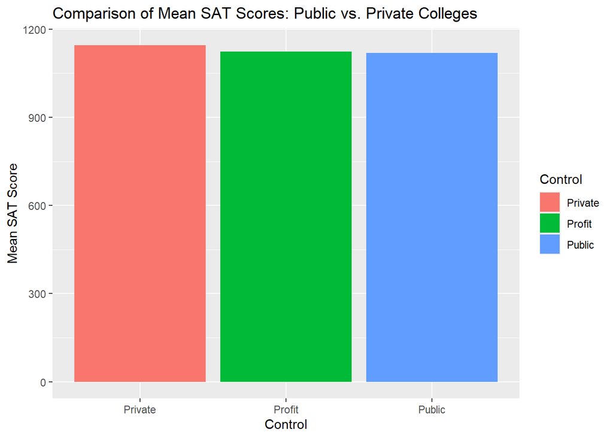

```r
college_data %>%
  group_by(Control) %>%
  summarise(avg_SAT = mean(AvgSAT, na.rm = TRUE)) %>%
  ggplot(aes(x = Control, y = avg_SAT, fill = Control)) +
  geom_bar(stat = "identity") +
  labs(title = "Comparison of Mean SAT Scores: Public vs. Private Colleges", y = "Mean SAT Score")
```

# 4 **Conclusion: Summary of Findings**

The analysis of the CollegeScores4yr dataset provides insights into key characteristics of U.S. colleges. The following conclusions can be drawn from the study:

1. Graduation Rates:

The average graduation rate among colleges is moderate, suggesting significant variation in student success rates across institutions.

2. SAT Scores:

The median SAT score provides a benchmark for typical academic performance required for admission. Private colleges may have slightly higher SAT requirements.

4. College Distribution by Region:

Colleges are unevenly distributed across regions, with some areas having a higher concentration of institutions.

5.Tuition Fees

The distribution of tuition fees indicates a wide range, with some colleges charging significantly more, particularly private institutions.

6. Acceptance Rates:

The boxplot analysis reveals outliers in acceptance rates, showing that some colleges have highly competitive admission processes.

9. Comparison of Tuition Fees:

Private colleges tend to charge significantly higher tuition fees than public institutions, as shown by the mean tuition comparison.

10. SAT Score Differences Between Public and Private Colleges:

Private colleges tend to have higher average SAT scores compared to public colleges, likely due to more selective admission policies.

Key Takeaways: